# Vowpal Wabbit

July 21st, 2015

## What is Vowpal Wabbit

Vowpal Wabbit (VW) is fast learning system developed at **Yahoo! Research** and **Microsoft Research** (now).

The core algorithm is sparse gradient descent on a loss function (several available)

Used in **Azure Machine Learning**

Wiki: https://github.com/JohnLangford/vowpal_wabbit/wiki

## Installation

- **Linux**
  - install Vowpal Wabbit package (Ubuntu: `apt-get install vowpal-wabbit`)
  - or install Boost library and then build VW from the source
- **Mac**
  - install Homebrew (http://brew.sh/)
  - run `brew install vowpal-wabbit`
- **Windows**
  - it's getting easier; you need MS Visual Studio
  - or install Cygwin and build everything from the source (boost and vw)

## Hello world

```bash
vw test.vw
```

```
Num weight bits = 18
learning rate = 0.5
initial_t = 0
power_t = 0.5
using no cache
Reading datafile = test.vw
num sources = 1
average    since         example     example  current  current  current
loss       last          counter      weight    label  predict features
1.000000   1.000000          1      1.0    -1.0000   0.0000       10
1.431072   1.862144          2      2.0     1.0000  -0.3646       11
1.364373   1.297674          4      4.0     1.0000  -0.1547        9

finished run
number of examples per pass = 6
passes used = 1
weighted example sum = 6
weighted label sum = 0
average loss = 1.21955
best constant = 0
best constant's loss = 1
total feature number = 58
```

## Hello world - input file

```bash
cat test.vw
```

```
-1 |cust 1 g=m age:34 |text I got the iPhone 5 |f hour:22
1 |cust 4 g=m |text I have had my iPhone 5S for |f hour:13
-1 |cust 2 g=f age:18 |text I have had 4 of these |f hour:21
1 |cust 5 g=m |text I don't know what others |f hour:12
-1 |cust 3 g=m age:34 |text £45. Yes. £45! I've bought |f hour:21
1 |cust 6 age:20 |text I don't understand all
```

```bash
cat minimal.vw
```

```
-1 | Well, I am now online ordering yet another cable for my
1 | There are a lot of poor reviews for this cable but I think
```

## Input format

Each line (example) has following format:

```r
[Label] [Importance] [Tag]|Namespace Features |Namespace Features ...
```

- Label: real number that we are trying to predict
- Importance: weight of this example
- Tag: Example identifier. Reported back during scoring
- Namespace: grouping and scaling of features (`|NamespaceName[:Scale]`)
- Features: name & value pairs (`Name[:Value]` or `NumericID[:Value]`)

Notes:

- Default value for `Scale` or `Value` is 1
- Omitting features means that value is 0
- Spacing is important!

## First model

```bash
vw vowpal_wabbit/test/train-sets/0002.dat -f model1.bin --invert_hash model1.txt
```

```
final_regressor = model1.bin
Num weight bits = 18
learning rate = 0.5
initial_t = 0
power_t = 0.5
using no cache
Reading datafile = vowpal_wabbit/test/train-sets/0002.dat
num sources = 1
average    since         example     example  current  current  current
loss       last          counter      weight    label  predict features
0.271591   0.271591          1      1.0     0.5211   0.0000       15
0.136121   0.000650          2      2.0     0.5353   0.5098       15
0.134500   0.132880          4      4.0     0.5854   0.8993       15
0.109463   0.084427          8      8.0     0.5575   0.4166       15
0.097540   0.085617         16     16.0     0.5878   0.3472       15
0.053619   0.009698         32     32.0     0.6038   0.6109       15
0.033864   0.014109         64     64.0     0.5683   0.4617       15
0.019961   0.006059        128    128.0     0.5351   0.4981       15
0.011687   0.003412        256    256.0     0.5385   0.5616       15
0.006936   0.002185        512    512.0     0.5053   0.5211       15

finished run
number of examples per pass = 1000
passes used = 1
weighted example sum = 1000
weighted label sum = 526.518
average loss = 0.00384728
best constant = 0.526518
total feature number = 14996
```

## First model - human readable output

```bash
cat model1.txt
```

[output not shown]

## Default commandline options

- squared loss function (`--loss_function`)
- Stochastic gradient descent (`--sgd`) update options:
  - adaptive (`--adaptive`): common features stabilize quickly
  - scale-free (`--normalized`): a.k.a `x' <- (x-μ)/σ`
  - importance invariant update (`--invariant`): dealing with the importance weights

## Online learning

- VW is online learner not batch learner
- one example at the time
- easily scale to billions of examples / features
- sensitive to input order
- multiple passes to help model converge (danger of over-fitting)

## Online learning - convergence

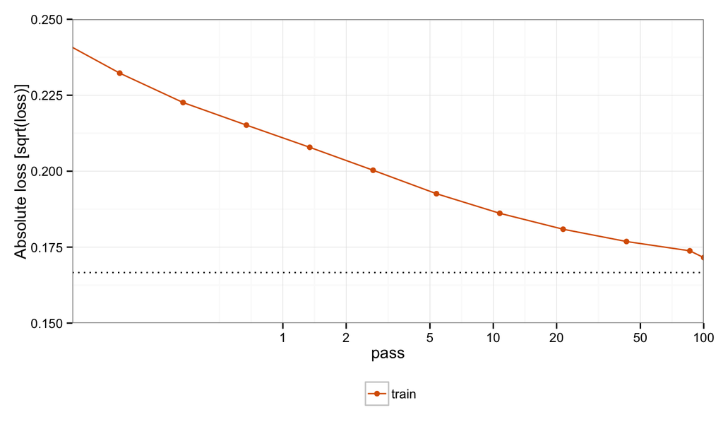

## Online learning - convergence

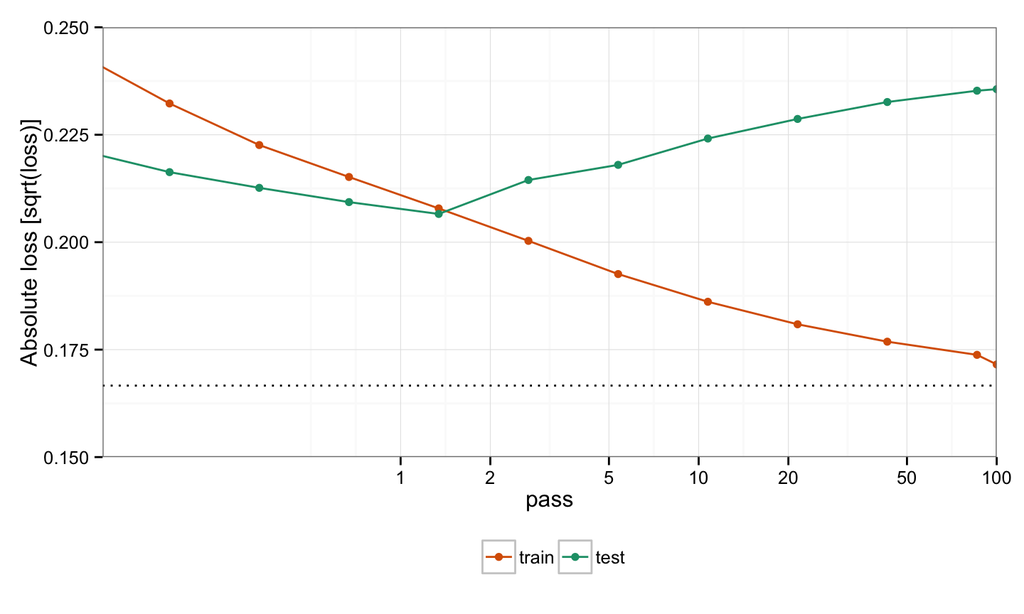

## Progressive validation

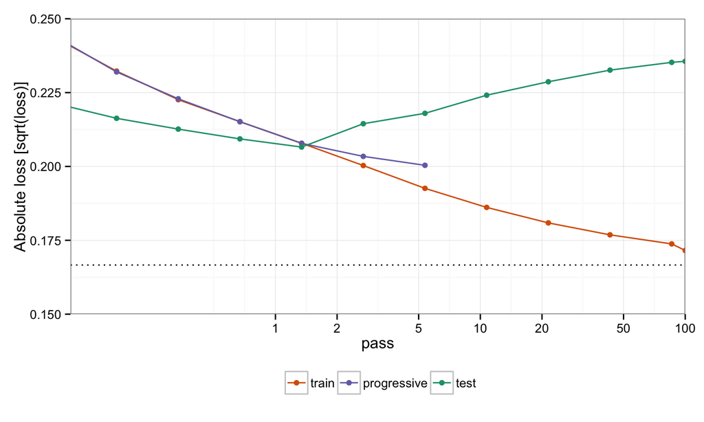

## Progressive validation

- enabled by default (`--holdout_off` to turn it off)
- set number of passes high enough (`--passes`)
- `--early_terminate` number of passes tolerated when holdout loss doesn't decrease
- cache must be used (`-c` or `--cache_file`, and `-k`)

## Train

- RCV1 data set: 781k examples; up to 40k features per example; 1.1G uncompressed

```bash
vw \
  # reproducible experiments
  --random_seed 1234 \
  # let's be specific about the cache file
  -k --cache_file rcv1.train.cache \
  # 10 passes should be enough
  --passes 10 \
  # save binary model`
  -f rcv1-model.bin \
  # save human readable model
  --readable_model rcv1-model.txt \
  # input file in vw format
  rcv1/rcv1.train.vw.gz
```

## Score / Test

```bash
vw \
  # Ignore label information and just test
  -t \
  # binary model file
  -i rcv1-model.bin \
  # save predictions
  -p rcv1-results.txt \
  rcv1/rcv1.test.vw.gz
```

```bash
head -n5 rcv1-results.txt
```

```
0.000000
1.000000
0.000000
0.000000
0.000000
```

## Trillions of features …

VW can create additional features on the fly

- quadratic (`-q`): across two namespaces
- cubic (`--cubic`): across three namespaces
- low rank quadratic features (`--lrq`, `--lrqdropout`): low-rank (N) approximations of quadratic interaction terms
- polynomial (`--stage_poly`): Nth degree polynomials
- n-skip-k-gram (`--ngram`, `--skips`)

## Trillions of features …

```bash
cat trillions.vw
```

```
1 |a hour:10 age:23 |b s=m income:1e5 commute>30m
-1 |a age:50 |b s=f income:1e5
1 |a hour:18 age:33 |b s=m commute>1h
-1 |a age:25 |b s=m
```

## Trillions of features …

```bash
vw --invert_hash model.txt -qab trillions.vw
```

```bash
cat model.txt | tail -n+12
```

```
Constant:116060:-0.089221
a^age:210600:-0.001649
a^age^b^commute>1h:233489:0.002522
a^age^b^commute>30m:65202:0.002982
a^age^b^income:39577:-0.000000
a^age^b^s=f:96508:-0.002458
a^age^b^s=m:140598:0.000471
a^hour:148190:0.007325
a^hour^b^commute>1h:133487:0.004623
a^hour^b^commute>30m:227344:0.006859
a^hour^b^income:201719:0.000000
a^hour^b^s=m:40596:0.007325
b^commute>1h:142345:0.083220
b^commute>30m:236202:0.068580
b^income:210577:-0.000000
b^s=f:5364:-0.122901
b^s=m:49454:0.001116
```

## Hashing trick

- feature name is hashed into fixed N-bit coefficient (model weights) space
- default is 18 bits (`-b`) => maximum 262 144 weights in model
- 1T features model requires 4TB of memory
- VW needs several MB

## Hashing trick

```bash
vw -b 2 --invert_hash 2b.txt trillions.vw
```

```bash
cat 2b.txt | tail -n+12
```

```
Constant:0:-0.002240
a^hour:2:0.022850
b^commute>1h:1:-0.000000
b^commute>30m:2:0.022850
b^income:1:-0.000000
b^s=m:2:0.022850
```

- `Constant` is hashed into 0
- `b^commute>1h`, `b^income` are hashed into 1
- `a^hour`, `b^commute>30m`, `b^s=m` are hashed into 2

## Hashing trick

How to avoid feature hashing?

- use numerical index as name
- avoid namespace
- avoid cubic, quadratic, … features
- do not use `--hash all`
- low `-b` creates collisions => set `-b` high enough to avoid collisions

```bash
cat numeric.vw
```

```
1 | 1:0.43534 2:123.232
-1 | 2:-0.03223 3:232
```

## Too many features

- include / exclude namespace (`--ignore`, `--keep`)
- use existing model (`--feature_mask`)

```bash
vw --l1 0.00001 -f mask.model data.vw
vw --feature_mask mask.model -f final.model data.vw
```

- L1 (`--l1`) and L2 (`--l2`) regularisation \[ \underset{w}{\text{min }} \sum_i (\lambda_1 \|w\|_1 + \frac{\lambda_2}{2} \Vert w \Vert_2^2 + \ell(x_i,y_i,w)) \]
- L1 via truncated gradient: small weights are truncated to 0

## Model debuging & inspection

- readable model (`--invert_hash, --readable_model`)
- change progress update frequency (`--progress`)
- audit mode (`--audit`)
- vw-varinfo

```bash
vowpal_wabbit/utl/vw-varinfo rcv1-20k.vw.gz | head -n 5
```

```
FeatureName    HashVal   MinVal   MaxVal    Weight   RelScore
f^140            35015     0.00     0.25   +3.0416    100.00%
f^886            35761     0.00     0.33   +2.0157     66.27%
f^2298           37173     0.00     0.10   +1.8732     61.59%
f^70             34945     0.00     0.26   +1.8428     60.59%
```

- and other scripts under `vowpal_wabbit/utl/`

## The missing bits

- (Cost-sensitive) One Against All (`--oaa`, `--csoaa`)
- Error Correcting Tournament (`--etc`)
- Weighted All Pairs (`--wap`)
- Contextual Bandit (`--cb`)
- Structured Prediction (search to learn) `--searn*`
- Active Learning (`--active*`)
- Topic Modeling (LDA) (`--lda*`)
- Matrix Factorization (`--rank`)
- Neural Network Reduction (`--nn`)
- Parallelisation

## Questions?

## Links

- Source: https://github.com/ondrejivanic/VowpalWabbitIntro
- VW: https://github.com/JohnLangford/vowpal_wabbit